# Overview

To practice some of the `ggplot2` customizations you’ve learned, we’re going to use two data sets. The first is a built-in dataset called `precip`, which contains data about the average amount of rainfall for various US cities. The second is an external dataset containing information about different Pokemon (from the popular video franchise).

## 0. Load the tidyverse package.

# Part 1: `precip`

## 1. The data in `precip` is not yet in a dataframe. Instead, it’s in a type of variable called a ‘named list’. To easily convert this to a dataframe (which we’ll name `rainfall`), we can use a `tidyverse` function called `enframe()`. We’ll write the code below to show you how to use this function, since we haven’t covered this in the workshop series.

Use the `head()` function to take a peek at what your dataframe contains. Notice that we have two columns, one with the name of the city and one with the number of inches of rain that fell in that city.

```
## # A tibble: 6 × 2
##   city        inches_rain
##   <chr>             <dbl>
## 1 Mobile             67
## 2 Juneau             54.7
## 3 Phoenix             7
## 4 Little Rock        48.5
## 5 Los Angeles        14
## 6 Sacramento         17.2
```

# 2. Create a bar plot using this data (using `geom_col`), with city on the x-axis and inches of rainfall on the y axis. Give your plot an informative title and axis labels.

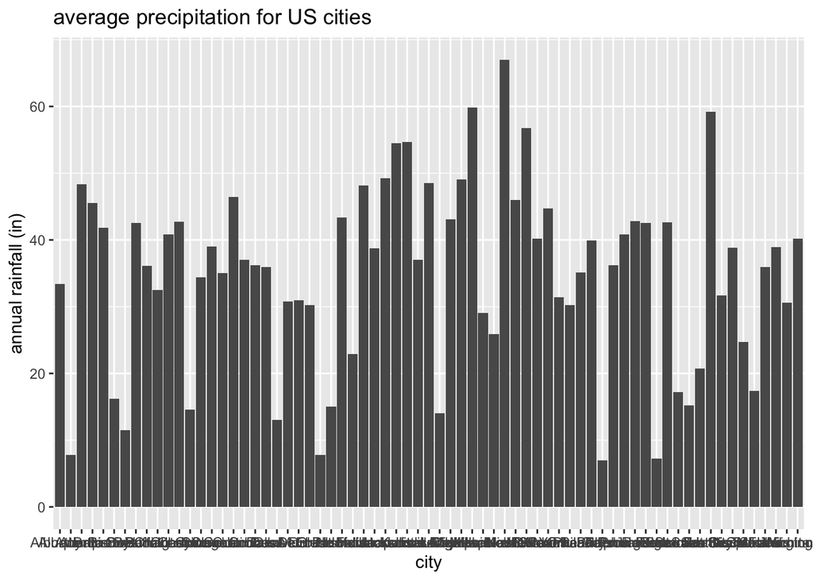

# 3. Now rotate the x-axis labels so they’re easier to read.

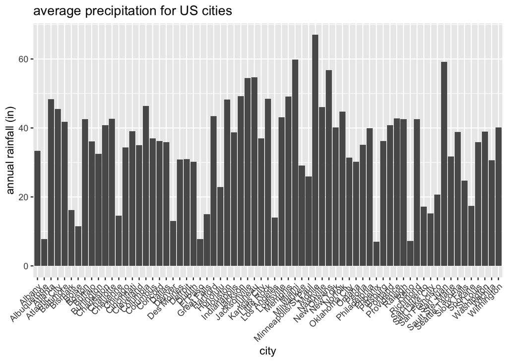

# 4. Reorder the bars on the x-axis so they show cities in the order of how much rainfall they received.

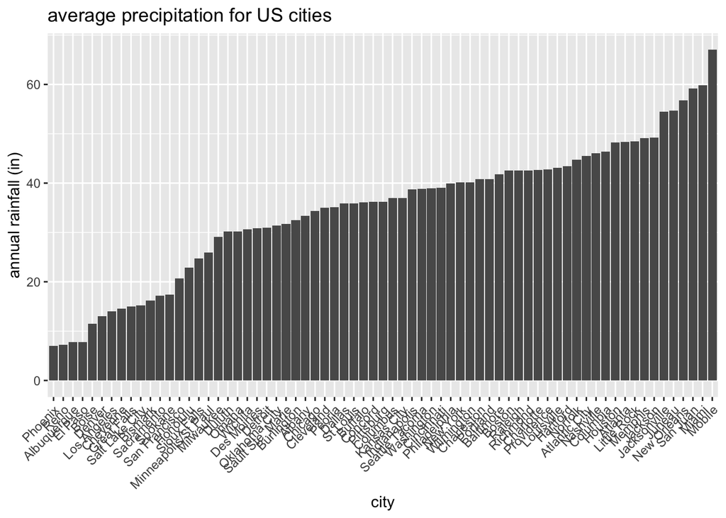

# 5. Change the fill of the bars according to how many inches of rain the city recieved.

Hint: This can be done by adding a `fill =` argument to the `aes()` function in `ggplot()`.

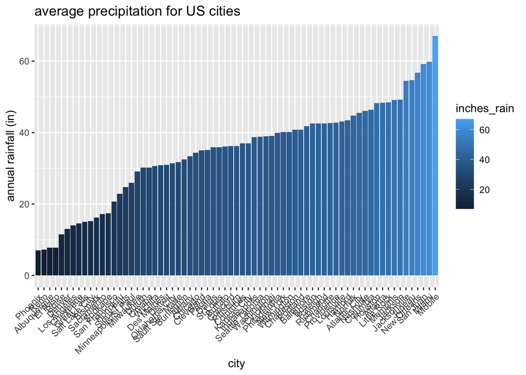

# 5b: BONUS: Change the color palette used in your plot by adding the function `scale_fill_viridis_c()` to your plot.

Note: In the workshop, we showed you how to use ColorBrewer to specify premade color palettes for categorical variables. R also contains some built-in palettes for continuous variables. For more info, see here: https://ggplot2-book.org/scale-colour.html#colour-continuous

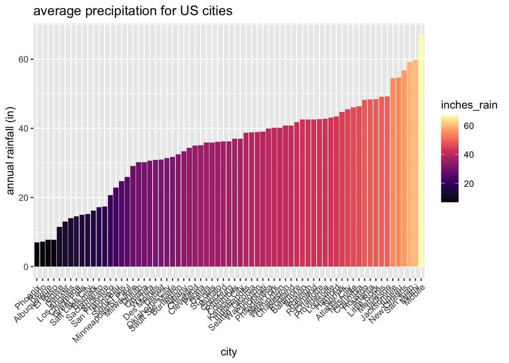

# 6. Compute the average rainfall across all the cities in the dataframe. Add a dashed horizontal line to the plot at this value and label it with text of your choice (e.g., ‘average rainfall across cities’).

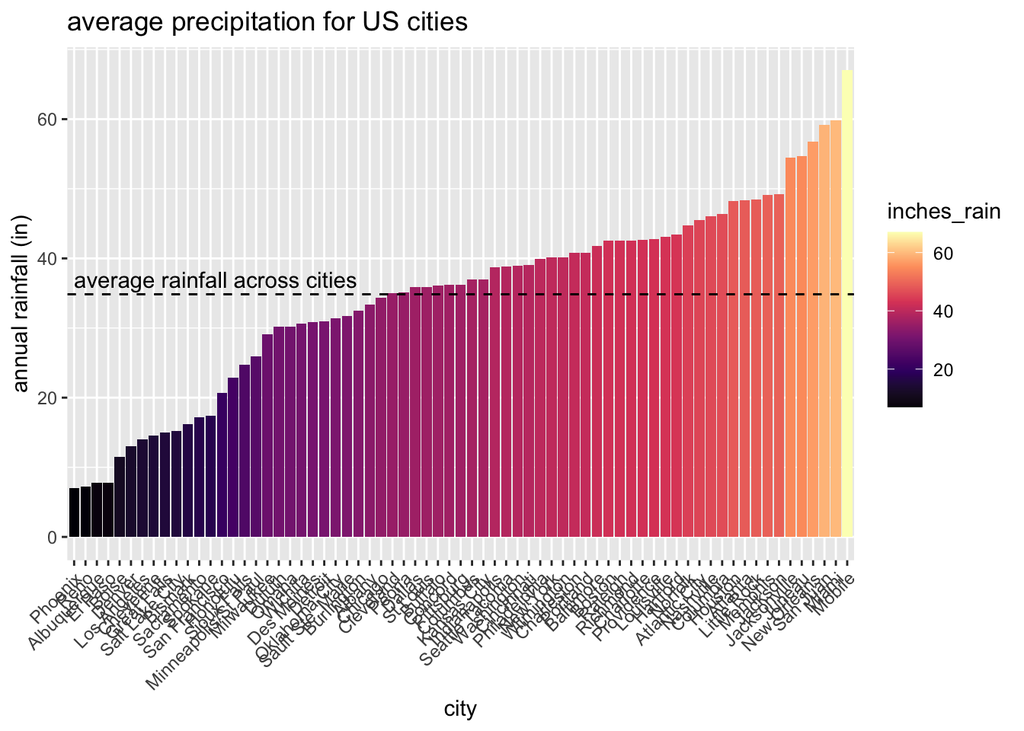

# 7. Change the theme to one of your choice, and also remove the legend.

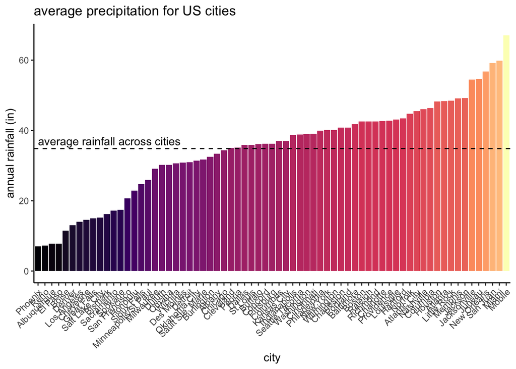

# Part 2

Now, let’s look at a new dataset that contains information about different Pokemon. See this page for more info about this dataset: https://www.kaggle.com/datasets/abcsds/pokemon

## 1. First, load in the `pokemon.csv` file and save it as a new dataframe. Print the first few rows so you can see what this dataset contains.

```
##   Number       Name Type1  Type2 Total HP Attack Defense SpAtk SpDef Speed
## 1      1  Bulbasaur Grass Poison   318 45     49      49    65    65    45
## 2      2    Ivysaur Grass Poison   405 60     62      63    80    80    60
## 3      3   Venusaur Grass Poison   525 80     82      83   100   100    80
## 4      4 Charmander  Fire          309 39     52      43    60    50    65
## 5      5 Charmeleon  Fire          405 58     64      58    80    65    80
## 6      6  Charizard  Fire Flying   534 78     84      78   109    85   100
##   Generation Legendary
## 1          1     FALSE
## 2          1     FALSE
## 3          1     FALSE
## 4          1     FALSE
## 5          1     FALSE
## 6          1     FALSE
```

## 2. Make a boxplot that depicts the speed stat of pokemon (in the `Speed` column) as a function of their primary type (in the `Type1` column). Make each type a different color, and add a title to the plot and change the axes labels if you’d like to.

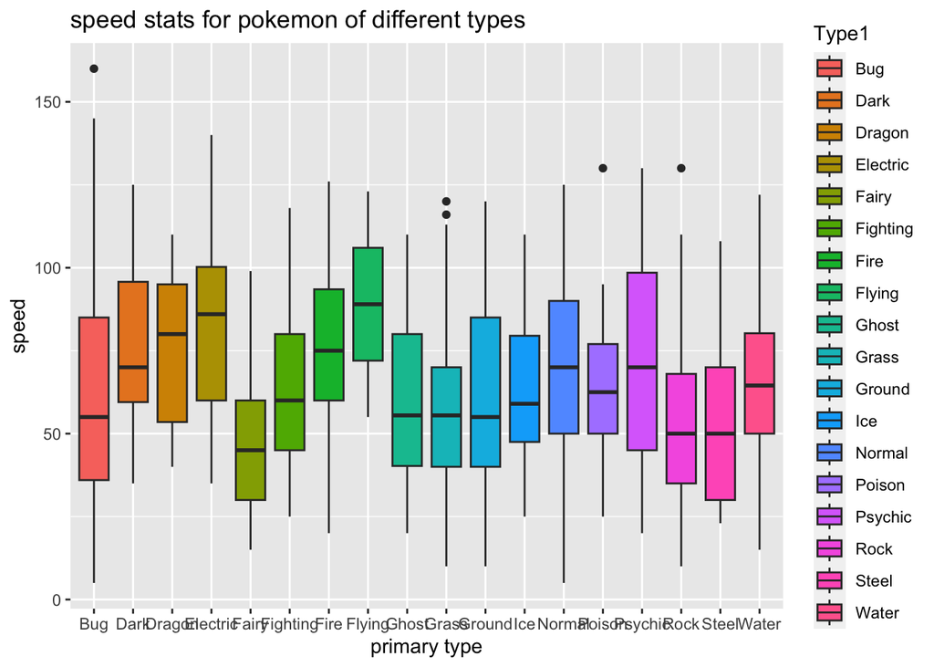

## 3. Let’s make a few more aesthetic adjustments. Remove the plot legend, and rotate the x-axis labels so they’re a little easier to read. Finally, use a different font of your choosing for the plot text.

Note: Not all fonts will work with ggplot, but try some of the ones that come by default on your computer. For modern Mac computers, this list should include fonts like ‘Avenir’, ‘Times’, and ‘Courier’.

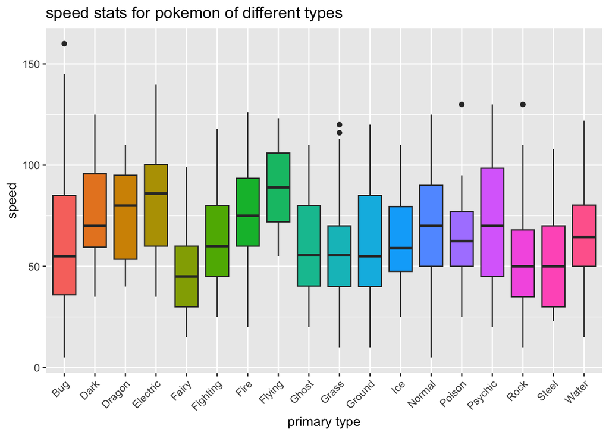

## 3b. BONUS: The `facet_wrap()` function is a really useful ggplot tool that allows you to easily subdivide your data into different subplots, or facets, that correspond to different levels of a categorical variable. Using this function, recreate the previous plot above (i.e., a boxplot showing the speed stats of different pokemon types), but create different facets for each pokemon `Generation`. Make it such that your new facetted plot has 3 columns and 2 rows. Optionally, add a subtitle to your plot to help clarify that each subplot corresponds to a different generation.

Hint: See this page (http://www.sthda.com/english/wiki/ggplot2-facet-split-a-plot-into-a-matrix-of-panels) for help with this function.

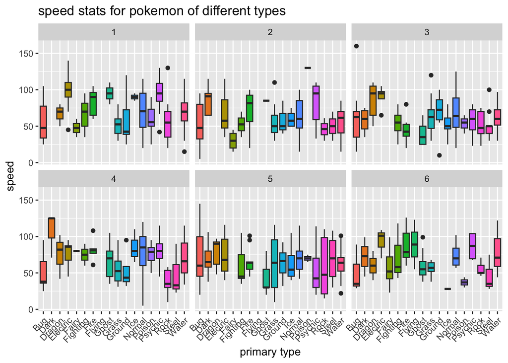

## 4. Next, let’s look closer at all the pokemon that are considered “legendary”. Filter the dataframe (using the `Legendary` column) to just include these pokemon. How many legendary pokemon are there?

```
##   Number     Name    Type1  Type2 Total  HP Attack Defense SpAtk SpDef Speed
## 1    144 Articuno      Ice Flying   580  90     85     100    95   125    85
## 2    145   Zapdos Electric Flying   580  90     90      85   125    90   100
## 3    146  Moltres     Fire Flying   580  90    100      90   125    85    90
## 4    150   Mewtwo  Psychic          680 106    110      90   154    90   130
## 5    243   Raikou Electric          580  90     85      75   115   100   115
## 6    244    Entei     Fire          580 115    115      85    90    75   100
##   Generation Legendary
## 1          1      TRUE
## 2          1      TRUE
## 3          1      TRUE
## 4          1      TRUE
## 5          2      TRUE
## 6          2      TRUE
```

```
## [1] 39
```

## 5. Now, create a scatter plot showing the `Attack` stat of the legendary pokemon on the x axis and the `Defense` stat on the y axis. Color the points according to the primary type (`Type1`).

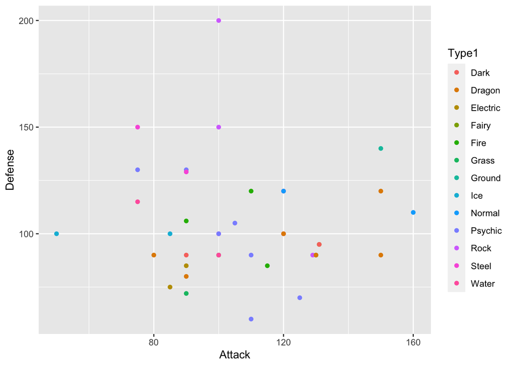

## 6. Increase the size of the points on the plot (as much as you want), and change their shape. Also add a title to your plot, and change the theme.

Note: A list of different point shapes can be found here: http://www.sthda.com/english/wiki/ggplot2-point-shapes

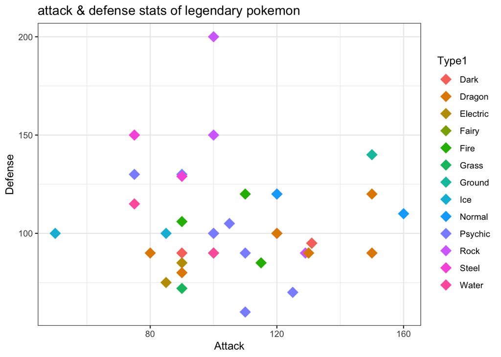

## 7. Figure out which two legendary pokemon have the highest `Attack` and `Defense` stats. Add text annotations to the plot depicting the names of these two pokemon next to their corresponding datapoint. You might needed to play around with the text alignment/coordinates to find a good spot for these annotations.

Note: If you want more of a challenge, you can figure out which pokemon these are using code. Alternatively, you can click the name of your dataframe in the Environment tab, which will open it in a new tab and allow you to sort the rows by different columns.

[figure not shown]